# IAPS Choice Task Analysis

Jonathan Trattner, Rachel Jones, and Delaney Teceno

Last compiled on August 01, 2020

## Introduction

The IAPS choice game is a 150-round two-choice probabilistic reward task that utilizes emotionally-stimulating images as outcomes. Participants are asked to choose between one of two icons that yield positive, neutral, or negative images varying in affective complexity. This task transitions through three phases in which participants are expected to learn which icons have the highest probability of resulting in a positive image.

Phase one includes 25 rounds with positive-only icons, where fixed probabilities of showing positive images are pre-determined (i.e. 25%, 50%, and 75% vs neutral). Phase two introduces negative-only icons with similar fixed probabilities of showing negative images per icon, which continues for 50 rounds. In these phases, each round shows pairs of positive icons or pairs of negative icons exclusively. However, in phase 3, all icons are mixed so that any round may consist of two positive icons, two negative icons, or one positive and one negative icon. In this phase, outcome magnitudes change giving rise to higher-complexity positive and negative images. The probabilities associated with each icon remain the same, altering the expected value of each option.

There is also a preference task at the beginning and ending of the choice game. Participants select one of two icons they prefer with no proceeding outcome. This is important to determine if certain characteristics of icons (i.e. color, laterality) influence participants’ choices throughout the game or if this changes because of image outcome.

### Read in the Data

Below, we read in the data and preview the raw text file output from the choice task.

```r
choiceFiles <- dir_ls('~/Desktop/IAPS/RJT/choice/', glob = "*.txt.txt") #get the paths for the files that contain the string ".txt.txt". For new cohort.

rawChoiceData <- map(choiceFiles, ~readChoices(.x), .id = "subject")

#preview raw choice data
head(as.data.frame(rawChoiceData[[1]]), 20)
```

|  | time | data |
| --- | --- | --- |
| 1 | 0000000000000 | Subject: IAPS_B_01 |
| 2 | 1594912717127 | KEYPRESS: n, leaving intro screen |
| 3 | 1594912724302 | Game Start by TTL - leaving ready screen |
| 4 | 1594912724302 | HOLD ... 4 secs ( for scanning ) |
| 5 | 1594912724302 | TR 1 |
| 6 | 1594912724302 | starting game |
| 7 | 1594912728305 | ICON TO GROUP MAPPING: {"icon33":2,"icon49":6,"icon02":4,"icon07":5,"icon28":1,"icon03":3} |
| 8 | 1594912728308 | SHOW: FORCED CHOICE INSTRUCTION SCREEN |
| 9 | 1594912733925 | KEYPRESS: 3, Continuing to next screen |
| 10 | 1594912733926 | HOLD ... 0.2 secs - fixed transition duration, ICON ROUND 0 |

[output cut: 10 more lines]

### Tidy the Data

Below, we tidy the data using the `iapsr` function `processChoiceData` and preview it. For information on how the processing was done, call `?iapsr::processChoiceData()` in the console. In summary, for each subject this function returns a dataframe 150 rows and 13 columns:

- phase: The phase the choices were made in.
- round: The round number these choices were made in, specific to the phase.
- runningRound: The round number these choices were made in (1-150), independent of phase. This is useful for plotting the percent of optimal choices over time.
- icon1: The icon presented in the first order position.
- rank1: The rank of icon1. The higher this is, the higher the expected utility of choosing icon1.
- icon2: The icon presented in the second order position.
- rank2: The rank of icon2. The higher this is, the higher the expected utility of choosing icon2.
- option: The option the subject chose. This should correspond to the icon order as presented in the task.
- choice: The icon the subject chose.
- group: The (payment weighting) group the chosen icon corresponds to.
- image: The image the subject was shown after making a choice.
- optimal: A binary variable tracking whether or not the choice was optimal. This is 1 if the rank of the icon chosen is higher than the rank of the one not chosen. It is 0 otherwise. The ranks are based on the expected utility for each icon. See getGroupInfo for that information.
- percentOptimal: The cumulative sum of optimal choices divided by the total round (1-150).

```r
finalChoiceData <- map_df(rawChoiceData, ~processChoiceData(.x), .id = "subject") %>%
  mutate(subject = str_extract(subject, "[:graph:]{9}(?=choice.txt)"))

finalChoiceData %>%
  head(10)
```

| subject | phase | round | runningRound | icon1 | rank1 | icon2 | rank2 | option | choice | group | image | optimal | percentOptimal |
| --- | --- | --- | --- | --- | --- | --- | --- | --- | --- | --- | --- | --- | --- |
| IAPS_B_01 | 1 | 1 | 1 | icon28 | 1 | icon03 | 3 | 1 | icon28 | 1 | neutral | 0 | 0 |
| IAPS_B_01 | 1 | 2 | 2 | icon03 | 3 | icon28 | 1 | 2 | icon28 | 1 | 5991 | 0 | 0 |
| IAPS_B_01 | 1 | 3 | 3 | icon03 | 3 | icon33 | 2 | 2 | icon33 | 2 | neutral | 0 | 0 |
| IAPS_B_01 | 1 | 4 | 4 | icon33 | 2 | icon28 | 1 | 2 | icon28 | 1 | neutral | 0 | 0 |
| IAPS_B_01 | 1 | 5 | 5 | icon28 | 1 | icon03 | 3 | 1 | icon28 | 1 | 3310 | 0 | 0 |
| IAPS_B_01 | 1 | 6 | 6 | icon03 | 3 | icon33 | 2 | 2 | icon33 | 2 | 4561 | 0 | 0 |
| IAPS_B_01 | 1 | 7 | 7 | icon03 | 3 | icon33 | 2 | 2 | icon33 | 2 | 2050 | 0 | 0 |
| IAPS_B_01 | 1 | 8 | 8 | icon03 | 3 | icon28 | 1 | 2 | icon28 | 1 | neutral | 0 | 0 |
| IAPS_B_01 | 1 | 9 | 9 | icon03 | 3 | icon28 | 1 | 2 | icon28 | 1 | neutral | 0 | 0 |
| IAPS_B_01 | 1 | 10 | 10 | icon03 | 3 | icon33 | 2 | 2 | icon33 | 2 | 4142 | 0 | 0 |

## Analyze Optimal Choices

Each subject is presented with a choice between two icons. In phase 1 there are three icons all leading to positively valenced images with varying probabilities. In phase 2 and 3 there are six icons; three lead to positively valenced images and three lead to negatively valenced images with differing probabilities. For instance, icon 1 might offer a reward equivalent to $1.00 in valence with probability 0.25 and icon 2 might offer a reward equivalent to $1.00 in valence with probability 0.5. Thus, the expected utility of icon 2 is greater than the expected utility of icon 1. This means that whenever an individual is presented with these two icons, the optimal choice is to choose icon 2.

Using the `getGroupInfo` function from the `iapsr` package, we get the reward-probability mappings for each icon per subject and then plot the cumulative sum of optimal choices.

### Percent Optimal Plot

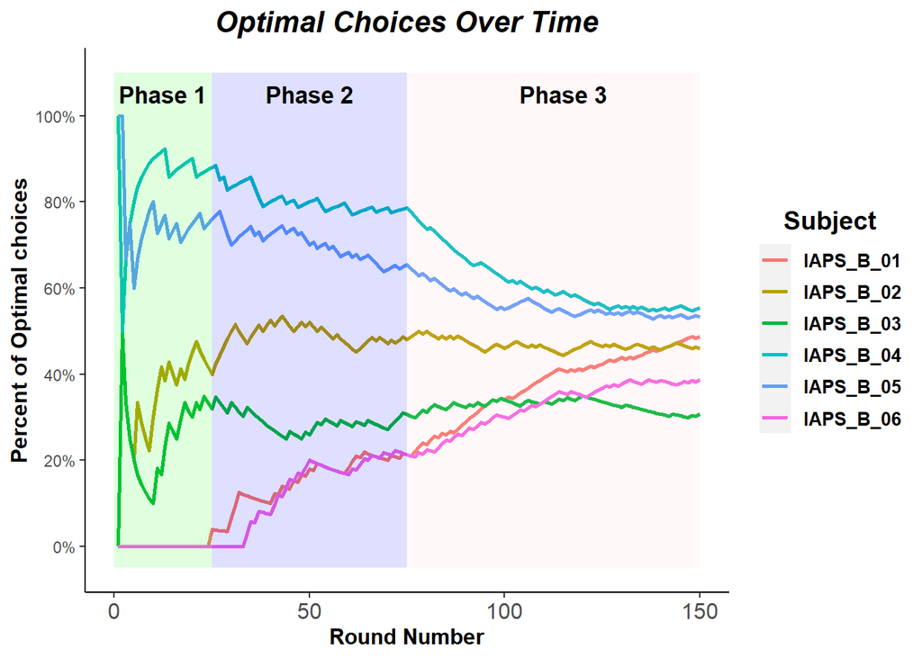

```r
finalChoiceData %>% plotPercentOptimal(facet = FALSE)
```

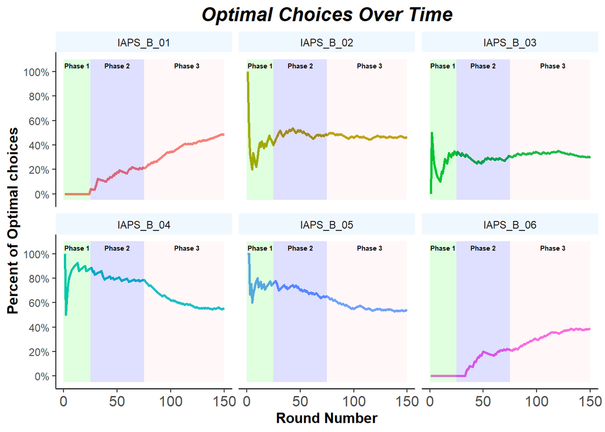

```r
finalChoiceData %>% plotPercentOptimal(facet = TRUE)
```